#### **To: Prof Green**

#### **From: Ralitza Mondal**

#### **Date: 10/04/2019**

#### **RE: Orange Juice Analysis**

Orange juice is a very good source of vitamin C. But the market provides two types Citrus Hill and Minute Maid. I was provided a sample of 1,070 observations. Withing the observations, I had to see which sells more often along with the variable of discount on the prices and special included during purchase.

I found that median price was a good indicator to look at prices of CH orange juice and MM orange juice from different stores, from store $1 sold the min of CH of $1.76and store $3 sold the most of cH of $1.99. At the same time, from store $1 sold the min of MM of $1.76 and store $2 sold the most of MM of $2.18. We took the median measure fore CH because the data was positively skewed where as MM didn’t show any skewness. There were about $236 more CH purchases.After investing where stores woud purchase more CH over MM. I discovered that CH was insensitive to price changes.

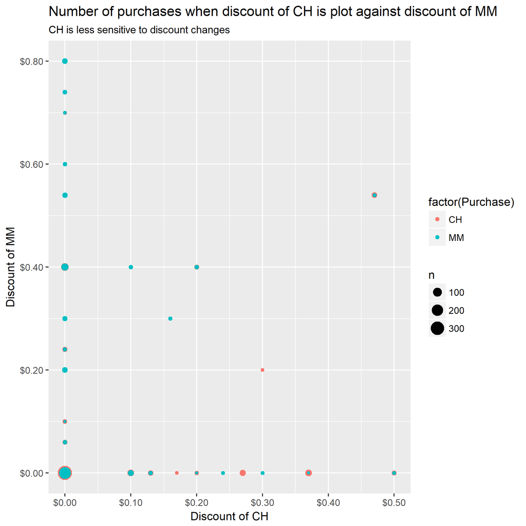

It appeasrs that At no dicount level people generally prefer CH over MM.Some instances we see people are also insensitive to the discount for MM, they still prefer CH even when there is a no discount for CH .There is also an instance when CH has a less discounted price than MM and people still prefer CH over MM.Because the sample size is too small, it would help to have additional variables such as population and income around the area to see why people are insentive to discount for CH and some stores sell more CH than others.

Sincerely, Ralitza